# Introduction to R

Joe Mills

8/24/2017

# What is R?

## Overview

- Interpreted language like Python
- Console

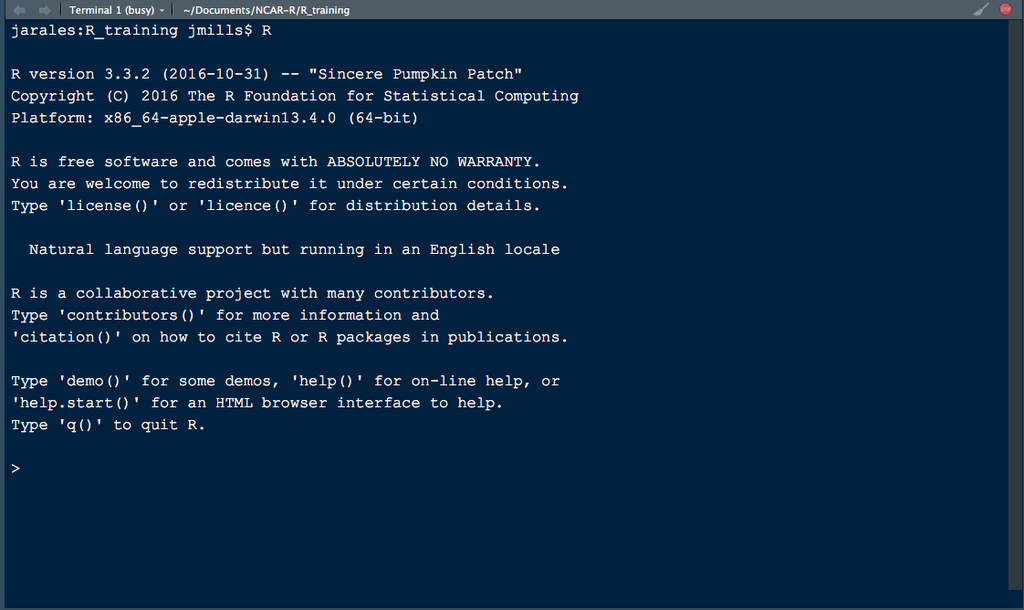

## Overview

- Has a ‘winning’ IDE
- R-Studio

[figure not shown]

## Basic syntax

Standard data types:

```r
integer, numeric, character, logical, Date, POSIXct, ...
```

Standard operators:

```r
+,*,>,<,==,!=, ...
```

Non-standard operator: The assignment operator `<-`

```r
x <- 1
y = 1
```

- Best practice is to **ALWAYS** use assignment operator, = reserved for function arguments

## Basic data structures

```r
#vectors - one data type
c('a','b','c')
c(1,2,3)

#matrices - one data type
matrix(c(1,2),c(4,5))

#lists - Multiple data types, can include names like Python
list('a',1,TRUE)
list(character = 'a', numeric = 1, logical = TRUE)

#dataframes - Multiple data types, the foundation of many R workflows, similar to Pandas.DataFrame
data.frame(site = c('site1','site2','site3'),
           var1 = c(1.1,2.2,3.3),
           var2 = as.Date(c('2016-01-01','2016-01-02','2016-01-03'))
)
```

- Note the () - functional language! Almost everything is a function

## Object oriented

Some object oriented programming as well with generic functions via methods and classes

```r
x <- runif(1:10)
y <- runif(1:10)

#Generic print function on a vector
print(x)
```

```
##  [1] 0.28672896 0.33879924 0.34177366 0.82632197 0.91749486 0.50355761
##  [7] 0.33512350 0.00800608 0.94581787 0.53357468
```

```r
#Generic print function on linear model object
linMod <- lm(x~y)
print(linMod)
```

```
##
## Call:
## lm(formula = x ~ y)
##
## Coefficients:
## (Intercept)            y
##      0.7340      -0.3569
```

# Extensible

## rwrfhydro

- R package developed by the NCAR WRF-Hydro group
- Library of tools (functions) to assist with various tasks related to WRF-Hydro
- Pre- and post-processing
- Publicly available and open for community code contributions
- https://github.com/NCAR/rwrfhydro

# The good, the bad, and what to do about it

## The Good

- Vibrant community of contributors in many scientific fields
- Exhaustive collection of domain-specific libraries for statistics and analysis
- Open source, build on and contribute to what others have done
- Generally reliable, well documented, and well vetted libraries
- **Graphics!**

## The Bad

- R is a language for analysis not a general purpose programming language means fewer and narrower range of libraries

| Language | Packages |
| --- | --- |
| R | 11282 |
| Python | 115361 |

- Capable, but not as ideal for deploying in production environments as other languages (e.g. Python)
- Base R library generally slow and memory intensive

## What to do about it

- Use a database to reduce the working size of your data problem
- Use optimized R packages written in C/C++ (data.table,dplyr,RcppRoll,etc…)
- Let a wrench be a wrench and a hammer be a hammer
- R is very good at working with relatively small (<~ 100 million rows) pieces of data in a very sophisticated way
- Let R do the sophisticated statistics, visualizations, and reporting
- Use another language if need be to do the production cleaning, aggregating, and storage tasks